# Predicting Weight Training Performance from Sensor Data

## Synopsis

The objective of this analysis is to predict weight training performance using sensor data. The original study collected data from accelerometers on the belt, forearm, arm, and dumbbell of 6 participants who were asked to perform barbell lifts correctly and incorrectly in 5 different ways. More information on the study is available from the website here: http://groupware.les.inf.puc-rio.br/har (see the section on the Weight Lifting Exercise Dataset).

After some minimal data preprocessing, a random forests model was fit to a subset of the available training data. The model achieved an in-sample error of less than 1%. The remaining training data was used for model validation, and the predicted out-of-sample error was also less than 1%.

## Data Processing

### Analysis System Information

```r
R.version$platform
```

```
## [1] "x86_64-apple-darwin13.1.0"
```

```r
R.version$version.string
```

```
## [1] "R version 3.1.0 (2014-04-10)"
```

### Data and Codebook

The analysis data was downloaded from https://d396qusza40orc.cloudfront.net/predmachlearn/pml-training.csv, and https://d396qusza40orc.cloudfront.net/predmachlearn/pml-testing.csv

```r
setwd("~/Documents/datasciencecoursera/PML Project")
train <- read.csv("./pml-training.csv")
dim(train)
```

```
## [1] 19622   160
```

The training data consists of 19622 observations of 160 variables. A more detailed description of the data is available here: http://groupware.les.inf.puc-rio.br/har

Briefly, however, the data consists of participant name, timestamp information, raw sensor data, summary sensor data, and a “classe” variable indicating whether the exercise was performed correctly or one of 4 varieties of incorrectness. Note that the index and timestamp information completely predict the classe variable.

### Data Pre-Processing

```r
library(caret)
set.seed(333)

trainRaw <- train[,c(8, 9, 10, 11, 37, 38, 39, 40, 41, 42, 43, 44, 45, 46, 47, 48, 49, 60, 61, 62, 63, 64, 65, 66, 67, 68, 84, 85, 86, 102, 113, 114, 115, 116, 117, 118, 119, 120, 121, 122, 123, 124, 140, 151, 152, 153, 154, 155, 156, 157, 158, 159, 160)]
#=================
# Split the training set into training and validation
#=================
inTrain <- createDataPartition(y=trainRaw$classe, p=.75, list=FALSE)
training <- trainRaw[inTrain,]
validation <- trainRaw[-inTrain,]

M <- abs(cor(training[,-53])); diag(M)<-0
which(M > .95, arr.ind=T)
```

```
##                  row col
## total_accel_belt   4   1
## accel_belt_z      10   1
## accel_belt_x       8   2
## roll_belt          1   4
## accel_belt_z      10   4
## pitch_belt         2   8
## roll_belt          1  10
## total_accel_belt   4  10
## gyros_dumbbell_z  33  31
## gyros_dumbbell_x  31  33
```

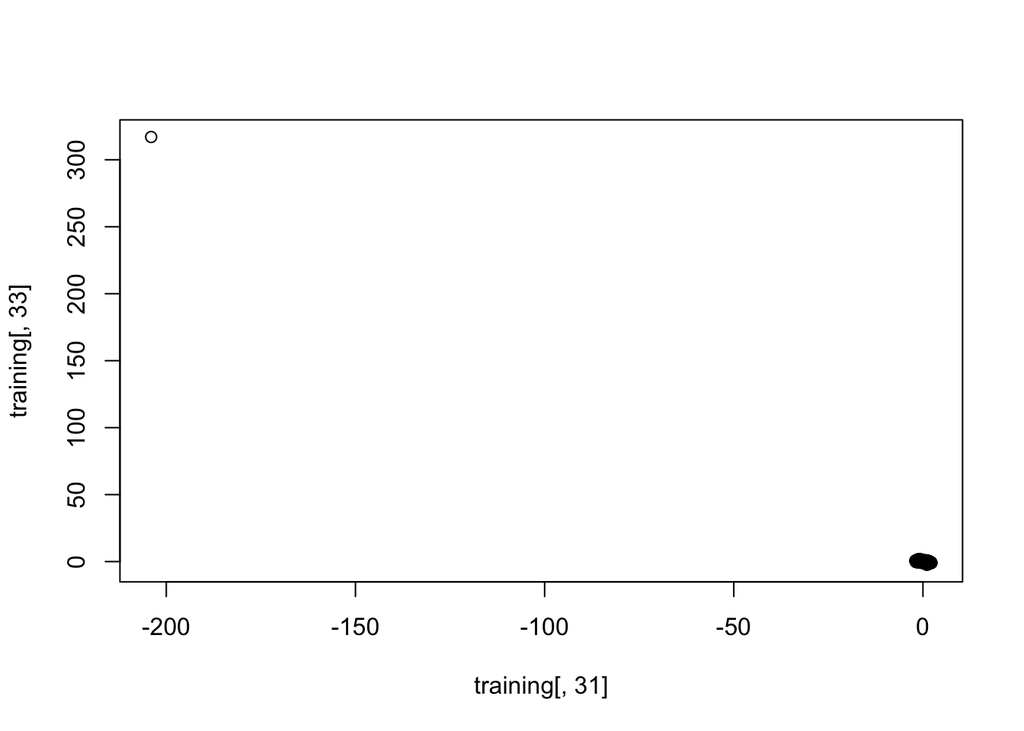

```r
plot(training[,31], training[,33])
```

```r
# Obvious outlier.  Probably a mistake.
# Remove from data
library(outliers)
outlier_tf = outlier(training$gyros_dumbbell_x, logical=TRUE)
find_outlier1=which(outlier_tf==TRUE, arr.ind=TRUE)
training2 <- training[-find_outlier1,]
# Again, a possible outlier in the accel_belt_x variable
outlier_tf = outlier(training2$accel_belt_x, logical=TRUE)
find_outlier2=which(outlier_tf==TRUE, arr.ind=TRUE)
training3 <- training2[-find_outlier2,]
```

The raw sensor data was subsetted for modeling (along with the response variable, “classe”), resulting in 52 prediction variables. The data was split into a training and validation set.

Some initial work was done to identify highly correlated variables; in the process several outlier points were found, which appeared to be data entry errors. They were removed from the training data.

## Model Building

```r
modFitRF <- train(classe ~., data=training3, method="rf", prox=TRUE,
                  trControl = trainControl(method = "cv", number = 4))
print(modFitRF)
```

```
## Random Forest
##
## 14716 samples
##    52 predictors
##     5 classes: 'A', 'B', 'C', 'D', 'E'
##
## No pre-processing
## Resampling: Cross-Validated (4 fold)
##
## Summary of sample sizes: 11037, 11038, 11037, 11036
##
## Resampling results across tuning parameters:
##
##   mtry  Accuracy  Kappa  Accuracy SD  Kappa SD
##   2     1         1      0.001        0.002
##   30    1         1      0.001        0.002
##   50    1         1      0.003        0.004
##
## Accuracy was used to select the optimal model using  the largest value.
## The final value used for the model was mtry = 2.
```

A number of different modeling techniques were attempted using the caret package on the training data. The models were then compared on the validation data. Those included trees (method=rpart), boosted trees (method=gbm), and linear discriminant analysis (method=lda). A random tree model (method=rf) was selected as having the lowest in-sample (training) and out-of-sample (validation) miss-classification error.

## Results

```r
print(modFitRF$finalModel)
```

```
##
## Call:
##  randomForest(x = x, y = y, mtry = param$mtry, proximity = TRUE)
##                Type of random forest: classification
##                      Number of trees: 500
## No. of variables tried at each split: 2
##
##         OOB estimate of  error rate: 0.56%
## Confusion matrix:
##      A    B    C    D    E class.error
## A 4182    2    0    0    0    0.000478
## B   13 2830    5    0    0    0.006320
## C    0   19 2546    2    0    0.008181
## D    0    0   36 2374    2    0.015755
## E    0    0    1    2 2702    0.001109
```

```r
prf <- predict(modFitRF, validation)
table(prf, validation$classe)
```

```
##
## prf    A    B    C    D    E
##   A 1395    5    0    0    0
##   B    0  941    5    0    0
##   C    0    3  848   10    2
##   D    0    0    2  794    2
##   E    0    0    0    0  897
```